# Advanced R, with Tidyverse

This is a worked set of answers to the Babraham R Tidyverse course

# Exercise 1 - Reading data into tibbles

First we are going to load the main tidyverse library. This will cause the loading of the main data loading and manipulation packages from the tidyverse

```r
library(tidyverse)
```

Now we can import our first file. The `small_file.txt` file is a tab delimited file, so we load it with read_tsv.

```r
read_tsv("small_file.txt") -> small.file
small.file
```

```
## # A tibble: 40 x 3
##    Sample Category Length
##    <chr>  <chr>     <dbl>
##  1 x_1    A            45
##  2 x_13   A            50
##  3 x_5    A            96
##  4 x_9    A            60
##  5 y_12   A            55
##  6 y_4    A            78
##  7 y_8    A            84
##  8 z_11   A            80
##  9 z_3    A            81
## 10 z_7    A            54
## # ... with 30 more rows
```

If we want to force the catgory column to be a factor then we can add a column definition to the column we want to change (all of the other columns are kept as they were).

```r
read_tsv("small_file.txt",
         col_types = cols(Category=col_factor())) -> small.file

small.file
```

```
## # A tibble: 40 x 3
##    Sample Category Length
##    <chr>  <fct>     <dbl>
##  1 x_1    A            45
##  2 x_13   A            50
##  3 x_5    A            96
##  4 x_9    A            60
##  5 y_12   A            55
##  6 y_4    A            78
##  7 y_8    A            84
##  8 z_11   A            80
##  9 z_3    A            81
## 10 z_7    A            54
## # ... with 30 more rows
```

Now we can see that `Category` is a factor, which doesn’t have any immediate effect but can be useful when plotting.

Now we can load the larger child_variants.csv file.

```r
read_csv("Child_Variants.csv") -> child.variants
```

This doesn’t work properly because the chromosome data is incorrectly parsed due to the first 1000 lines being all numbers, and the lettered chromosomes don’t appear until later.

We can fix this by either increasing the number of lines R uses to guess the file formats, or by adding a column type specification when we load. We only need to define the types for the columns which are incorrectly guessed.

If we were to increase the guess size we would use

```r
read_csv("Child_Variants.csv", guess_max = 1000000) -> child.variants
```

If we wanted to specifically identify the column we want to change then we’d use:

```r
read_csv(
  "Child_Variants.csv",
  col_types=cols(
    CHR=col_character()
  )
) -> child.variants

child.variants
```

```
## # A tibble: 25,822 x 11
##    CHR      POS dbSNP REF   ALT    QUAL GENE  ENST  MutantReads COVERAGE
##    <chr>  <dbl> <chr> <chr> <chr> <dbl> <chr> <chr>       <dbl>    <dbl>
##  1 1      69270 .     A     G        16 OR4F5 ENST~           3        4
##  2 1      69511 rs75~ A     G       200 OR4F5 ENST~          24       27
##  3 1      69761 .     A     T       200 OR4F5 ENST~           8        8
##  4 1      69897 rs75~ T     C        59 OR4F5 ENST~           3        3
##  5 1     877831 rs66~ T     C       200 SAMD~ ENST~          10       11
##  6 1     881627 rs22~ G     A       200 NOC2L ENST~          52       56
##  7 1     887801 rs38~ A     G       200 NOC2L ENST~          47       48
##  8 1     888639 rs37~ T     C       200 NOC2L ENST~          23       24
##  9 1     888659 rs37~ T     C       200 NOC2L ENST~          17       21
## 10 1     889158 rs13~ G     C       200 NOC2L ENST~          25       28
## # ... with 25,812 more rows, and 1 more variable: MutantReadPercent <dbl>
```

We can now plot out a plot looking at the coverage of each variant against the chromosome it comes from.

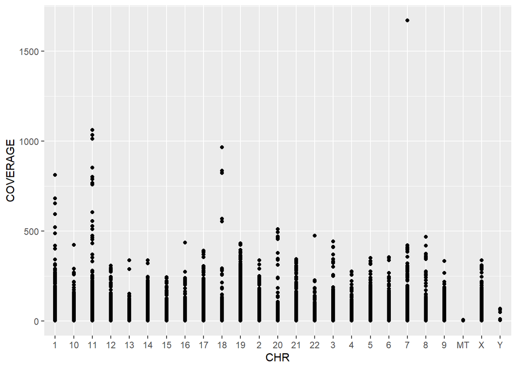

```r
child.variants %>%
  ggplot(aes(x=CHR, y=COVERAGE)) +
  geom_point()
```

# Exercise 2 - Filtering and Selecting with dplyr

We’re going to read in the `genomes.csv` file.

```r
read_csv("genomes.csv") -> genomes
head(genomes)
```

```
## # A tibble: 6 x 7
##   Organism       Groups          Size Chromosomes Organelles Plasmids Assemblies
##   <chr>          <chr>          <dbl>       <dbl>      <dbl>    <dbl>      <dbl>
## 1 'Brassica nap~ Bacteria;Terr~ 0.744           0          0        0          1
## 2 'Candidatus K~ Bacteria;FCB ~ 3.27            0          0        0          1
## 3 'Catharanthus~ Bacteria;Terr~ 0.604           1          0        1          1
## 4 'Chrysanthemu~ Bacteria;Terr~ 0.740           0          0        0          1
## 5 'Echinacea pu~ Bacteria;Terr~ 0.545           0          0        0          1
## 6 'Osedax' symb~ Bacteria;uncl~ 4.02            0          0        0          1
```

Now we’re going to do some basic filtering.

Find the organisms with more than 40 chromosomes. I’ll only show selected columns to make the output easier to see:

```r
genomes %>%
  filter(Chromosomes > 40) %>%
  select(Organism, Chromosomes)
```

```
## # A tibble: 6 x 2
##   Organism                       Chromosomes
##   <chr>                                <dbl>
## 1 Carassius auratus                       59
## 2 Chiloscyllium plagiosum                 51
## 3 Cyprinus carpio                         50
## 4 Glypta fumiferanae ichnovirus          105
## 5 Hyposoter fugitivus ichnovirus          56
## 6 Thymallus thymallus                     51
```

Do any organisms containing a plasmid also have more than one chromosome?

```r
genomes %>%
  filter(Plasmids > 0) %>%
  filter(Chromosomes > 1) %>%
  select(Organism, Chromosomes, Plasmids)
```

```
## # A tibble: 96 x 3
##    Organism                  Chromosomes Plasmids
##    <chr>                           <dbl>    <dbl>
##  1 Agrobacterium fabrum                2        2
##  2 Agrobacterium tumefaciens           2        3
##  3 Agrobacterium vitis                 2        5
##  4 Aliivibrio fischeri                 2        1
##  5 Aliivibrio salmonicida              2        4
##  6 Aliivibrio wodanis                  2        4
##  7 Asticcacaulis excentricus           2        2
##  8 Brassica napus                     19        1
##  9 Burkholderia ambifaria              3        1
## 10 Burkholderia cepacia                3        1
## # ... with 86 more rows
```

Make a list of the 10 organisms with the largest genomes:

```r
genomes %>%
  arrange(desc(Size)) %>%
  slice(1:10) %>%
  select(Organism, Size)
```

```
## # A tibble: 10 x 2
##    Organism                   Size
##    <chr>                     <dbl>
##  1 Ambystoma mexicanum      32396.
##  2 Pinus lambertiana        27603.
##  3 Sequoia sempervirens     26537.
##  4 Picea glauca             24633.
##  5 Pinus taeda              22104.
##  6 Pseudotsuga menziesii    14673.
##  7 Triticum aestivum        14547.
##  8 Triticum dicoccoides     10678.
##  9 Hordeum vulgare           9789.
## 10 Sequoiadendron giganteum  8122.
```

Make a version of the data with Groups removed

```r
genomes %>%
  select(-Groups)
```

```
## # A tibble: 47,211 x 6
##    Organism                      Size Chromosomes Organelles Plasmids Assemblies
##    <chr>                        <dbl>       <dbl>      <dbl>    <dbl>      <dbl>
##  1 'Brassica napus' phytopla~ 0.744             0          0        0          1
##  2 'Candidatus Kapabacteria'~ 3.27              0          0        0          1
##  3 'Catharanthus roseus' ast~ 0.604             1          0        1          1
##  4 'Chrysanthemum coronarium~ 0.740             0          0        0          1
##  5 'Echinacea purpurea' witc~ 0.545             0          0        0          1
##  6 'Osedax' symbiont bacteri~ 4.02              0          0        0          1
##  7 'Sphingomonas ginsengisol~ 3.04              0          0        0          1
##  8 Abaca bunchy top virus     0.00642           6          0        0          2
##  9 Abalone herpesvirus Victo~ 0.212             1          0        0          1
## 10 Abalone shriveling syndro~ 0.0350            1          0        0          1
## # ... with 47,201 more rows
```

Select the columns which start with “O”

```r
genomes %>%
  select(starts_with("O"))
```

```
## # A tibble: 47,211 x 2
##    Organism                                        Organelles
##    <chr>                                                <dbl>
##  1 'Brassica napus' phytoplasma                             0
##  2 'Candidatus Kapabacteria' thiocyanatum                   0
##  3 'Catharanthus roseus' aster yellows phytoplasma          0
##  4 'Chrysanthemum coronarium' phytoplasma                   0
##  5 'Echinacea purpurea' witches'-broom phytoplasma          0
##  6 'Osedax' symbiont bacterium Rs2_46_30_T18                0
##  7 'Sphingomonas ginsengisoli' Hoang et al. 2012            0
##  8 Abaca bunchy top virus                                   0
##  9 Abalone herpesvirus Victoria/AUS/2009                    0
## 10 Abalone shriveling syndrome-associated virus             0
## # ... with 47,201 more rows
```

How many different groups are there?

```r
genomes %>%
  distinct(Groups) %>%
  nrow()
```

```
## [1] 310
```

Plot a scatterplot of the number of chromosomes vs the genome size but showing only one organism for each chromosome number. When deduplicating keep only the smallest genome for each chromosome number. Exclude organisms with no listed chromosomes.

To make this clearer I’m going to select only the columns I’m using. This isn’t necessary (the rest of the code will still work if I don’t do this), but it makes it a little easier to see what’s going on whilst developing the chain of operations.

In the final plot the linear scaling of chromosome size wasn’t all that informative so I plotted it on the log size which shows the overall trend more clearly.

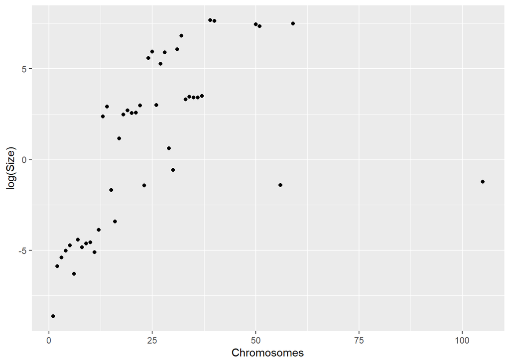

```r
genomes %>%
  select(Chromosomes, Size) %>%
  arrange(Size) %>%
  filter(Chromosomes > 0) %>%
  distinct(Chromosomes, .keep_all = TRUE) %>%
  ggplot(aes(x=Chromosomes, y=log(Size))) +
  geom_point()
```

# Exercise 3 - More clever filtering

```r
read_csv("cancer_stats.csv") -> cancer
head(cancer)
```

```
## # A tibble: 6 x 6
##   Class      Site      `Male Cases` `Female Cases` `Male Deaths` `Female Deaths`
##   <chr>      <chr>            <dbl>          <dbl>         <dbl>           <dbl>
## 1 Oral       Tongue           12550           4510          2220             800
## 2 Oral       Mouth             8430           5880          1800             940
## 3 Oral       Pharynx          14450           3420          2660             790
## 4 Digestive~ Eosophag~        13750           3900         13020            3060
## 5 Digestive~ Stomach          17230          10280          6800            4340
## 6 Digestive~ Small in~         5610           1980           890             700
```

For which Digestive System cancer types are there more female cases than male cases?

Since these two test are combined with an AND logic we can either put them in a single filter statement or we could chain two filter statements together.

This is the first place where we have column names with spaces in them, and therefore where they need to be quoted. We can’t put them in single or double quotes otherwise they’ll be treated as text, so we use backticks. By far the easiest way to get the quoting right is to select from the drop down list in RStudio which will handle this for you.

```r
cancer %>%
  filter(Class=="Digestive System" & `Female Cases` > `Male Cases`)
```

```
## # A tibble: 1 x 6
##   Class          Site  `Male Cases` `Female Cases` `Male Deaths` `Female Deaths`
##   <chr>          <chr>        <dbl>          <dbl>         <dbl>           <dbl>
## 1 Digestive Sys~ gall          5810           6550          1610            2350
```

Which cancer types have NA values for either male or female.

```r
cancer %>%
  filter(is.na(`Male Cases`))
```

```
## # A tibble: 5 x 6
##   Class   Site         `Male Cases` `Female Cases` `Male Deaths` `Female Deaths`
##   <chr>   <chr>               <dbl>          <dbl>         <dbl>           <dbl>
## 1 genital cervix                 NA          13170            NA            4250
## 2 genital uterine cor~           NA          61880            NA           12160
## 3 genital Ovary                  NA          22530            NA           13980
## 4 genital Vulva                  NA           6070            NA            1280
## 5 genital female geni~           NA           5350            NA            1430
```

```r
cancer %>%
  filter(is.na(`Female Cases`))
```

```
## # A tibble: 3 x 6
##   Class   Site         `Male Cases` `Female Cases` `Male Deaths` `Female Deaths`
##   <chr>   <chr>               <dbl>          <dbl>         <dbl>           <dbl>
## 1 genital Prostate           174650             NA         31620              NA
## 2 genital Testis               9560             NA           410              NA
## 3 genital male genital         2080             NA           410              NA
```

I guess that makes sense.

Which cancer type has the best survival rate for males?

In reality it might be better to add a survival column to the data and then filter on that, but since we haven’t seen how to do that yet we’ll settle for doing it directly in the filter.

```r
cancer %>%
  select(Class, Site, `Male Cases`, `Male Deaths`) %>%
  arrange(`Male Deaths`/`Male Cases`) %>%
  slice(1)
```

```
## # A tibble: 1 x 4
##   Class   Site   `Male Cases` `Male Deaths`
##   <chr>   <chr>         <dbl>         <dbl>
## 1 genital Testis         9560           410
```

Which Sites have acute in their name?

```r
cancer %>%
  filter(str_detect(Site,"acute"))
```

```
## # A tibble: 2 x 6
##   Class   Site         `Male Cases` `Female Cases` `Male Deaths` `Female Deaths`
##   <chr>   <chr>               <dbl>          <dbl>         <dbl>           <dbl>
## 1 leukem~ acute lymph~         3280           2650           850             650
## 2 leukem~ acute myelo~        11650           9800          6290            4630
```

Out of tongue, kidney, breast and pancreas, which is classified as a soft tissue cancer?

We can do this by initially making a vector of the things we want to test.

```r
c("tongue","kidney","breast","pancreas") -> tissues.to.test
```

Now we can find those tissues in the whole dataset

```r
cancer %>%
  filter(Site %in% tissues.to.test)
```

```
## # A tibble: 3 x 6
##   Class         Site   `Male Cases` `Female Cases` `Male Deaths` `Female Deaths`
##   <chr>         <chr>         <dbl>          <dbl>         <dbl>           <dbl>
## 1 Digestive Sy~ pancr~        29940          26830         23800           21950
## 2 soft tissue   breast         2670         268600           500           41760
## 3 urinary       kidney        44120          29700          9820            4950
```

But there’s a problem - where’s tongue? It’s not there because it’s spelled with a capital T in the original data. How could we do the filtering to ignore case? We can do it by transforming the data to lower case as we do the test. The preserves the original case in the result, but allows for case insensitive matches.

```r
cancer %>%
  filter(tolower(Site) %in% tissues.to.test)
```

```
## # A tibble: 4 x 6
##   Class         Site   `Male Cases` `Female Cases` `Male Deaths` `Female Deaths`
##   <chr>         <chr>         <dbl>          <dbl>         <dbl>           <dbl>
## 1 Oral          Tongue        12550           4510          2220             800
## 2 Digestive Sy~ pancr~        29940          26830         23800           21950
## 3 soft tissue   breast         2670         268600           500           41760
## 4 urinary       kidney        44120          29700          9820            4950
```

Now we can do ahead and find the answer to the original question

```r
cancer %>%
  filter(tolower(Site) %in% tissues.to.test) %>%
  filter(Class=="soft tissue")
```

```
## # A tibble: 1 x 6
##   Class       Site   `Male Cases` `Female Cases` `Male Deaths` `Female Deaths`
##   <chr>       <chr>         <dbl>          <dbl>         <dbl>           <dbl>
## 1 soft tissue breast         2670         268600           500           41760
```

Find sites with 4 or fewer letters in their name.

For this we’ll need to use a transformation of the text to its length when filtering. We can either do this with the core `nchar` function, or the stringr `str_length` function.

```r
cancer %>%
  filter(str_length(Site) <=4 )
```

```
## # A tibble: 4 x 6
##   Class          Site  `Male Cases` `Female Cases` `Male Deaths` `Female Deaths`
##   <chr>          <chr>        <dbl>          <dbl>         <dbl>           <dbl>
## 1 Digestive Sys~ gall          5810           6550          1610            2350
## 2 respiritory    lung        116440         111710         76650           66020
## 3 bone           bone          2030           1470           960             700
## 4 soft tissue    skin         62320          42030          8030            3620
```

Find all sites whose name ends with a “Y”.

```r
cancer %>%
  filter(endsWith(Site,"y"))
```

```
## # A tibble: 2 x 6
##   Class   Site   `Male Cases` `Female Cases` `Male Deaths` `Female Deaths`
##   <chr>   <chr>         <dbl>          <dbl>         <dbl>           <dbl>
## 1 urinary kidney        44120          29700          9820            4950
## 2 genital Ovary            NA          22530            NA           13980
```

# Exercise 4 - Restructuring data into ‘tidy’ format

We are going to look through a few different files to see how they can be restructured. In each case we can ask the following questions:

1. How many types of measurement are there
2. Does the same type of measurement appear in more than one column? If so how can we put them all in one column
3. Are there any combined categorical variables which should be split apart?
4. Are there any repeated annotation values which would be better split off into another table?
5. Does the restructured data contain and NA values which would be better off being removed?

## tidy_data1

```r
read_csv("tidy_data1.csv") -> tidy1
tidy1
```

```
## # A tibble: 17 x 4
##     DMSO `TGX-221` PI103  Akt1
##    <dbl>     <dbl> <dbl> <dbl>
##  1 144.       99.6  42.0 112.
##  2 136.      115.   57.5 124.
##  3  57.9     106.   41.0 127.
##  4  66.7     116.   63.1 131.
##  5  73.4      76.0  NA    88.6
##  6  83.4      NA    NA   148.
##  7  97.4      NA    NA    72.7
##  8  97.9      NA    NA    82.7
##  9 108.       NA    NA    49.6
## 10 113.       NA    NA    NA
## 11 110.       NA    NA    NA
## 12 133.       NA    NA    NA
## 13  75.5      NA    NA    NA
## 14 104.       NA    NA    NA
## 15 105.       NA    NA    NA
## 16  95.3      NA    NA    NA
## 17 113.       NA    NA    NA
```

This dataset has only one type of measurement, but it is split over 4 columns. The sample names are all OK already and there is no additional annotation so there’s nothing else to do once we’ve combined the whole dataset into a key/value pair.

For the `cols` argument we need to select all columns. We could do this in a number of ways;

- `DMSO:Akt1`
- `1:last_col()`

..but we’ll use the simpler `everything()` function to get the lot in one go.

```r
tidy1 %>%
  pivot_longer(cols=everything(), names_to = "Sample", values_to = "Value") -> tidy1

tidy1
```

```
## # A tibble: 68 x 2
##    Sample  Value
##    <chr>   <dbl>
##  1 DMSO    144.
##  2 TGX-221  99.6
##  3 PI103    42.0
##  4 Akt1    112.
##  5 DMSO    136.
##  6 TGX-221 115.
##  7 PI103    57.5
##  8 Akt1    124.
##  9 DMSO     57.9
## 10 TGX-221 106.
## # ... with 58 more rows
```

Although this is better, if we look towards the end of the file we can see that there are still NA values in there.

```r
tail(tidy1)
```

```
## # A tibble: 6 x 2
##   Sample  Value
##   <chr>   <dbl>
## 1 PI103     NA
## 2 Akt1      NA
## 3 DMSO     113.
## 4 TGX-221   NA
## 5 PI103     NA
## 6 Akt1      NA
```

We can use a filter to remove these.

```r
tidy1 %>%
  filter(!is.na(Value)) -> tidy1

tidy1
```

```
## # A tibble: 35 x 2
##    Sample  Value
##    <chr>   <dbl>
##  1 DMSO    144.
##  2 TGX-221  99.6
##  3 PI103    42.0
##  4 Akt1    112.
##  5 DMSO    136.
##  6 TGX-221 115.
##  7 PI103    57.5
##  8 Akt1    124.
##  9 DMSO     57.9
## 10 TGX-221 106.
## # ... with 25 more rows
```

## tidy_data2

```r
read_csv("tidy_data2.csv") -> tidy2
tidy2
```

```
## # A tibble: 12 x 10
##    ID               Chr      Start      End Strand     A     B     C     D     E
##    <chr>            <chr>    <dbl>    <dbl> <chr>  <dbl> <dbl> <dbl> <dbl> <dbl>
##  1 ENSMUSG00000026~ 1       5.84e7   5.84e7 -       0.4   0.26  0.24  1.04  0.74
##  2 ENSMUSG00000059~ 4       1.09e8   1.09e8 -       1.5   0.47  0.25  2.78  0.99
##  3 ENSMUSG00000029~ 5       1.45e8   1.45e8 +       0.98  0.42  1.01  0.82  1.26
##  4 ENSMUSG00000030~ 6       1.13e8   1.13e8 +       0.33  0.64  0.77  1.65  1.5
##  5 ENSMUSG00000030~ 7       8.03e7   8.03e7 -       0.75  0.32  0.47  0.49  0.3
##  6 ENSMUSG00000030~ 7       1.22e8   1.22e8 -       1.48  0.65  0.47  0.97  0.34
##  7 ENSMUSG00000069~ 8       3.46e6   3.47e6 -       1.18  0.43  0.46  1.39  0.77
##  8 ENSMUSG00000053~ 9       1.07e8   1.07e8 -       0.33  0.67  0.65  3.24  1.94
##  9 ENSMUSG00000052~ 9       1.08e8   1.08e8 +       1.42  0.43  0.41  1.12  2.62
## 10 ENSMUSG00000046~ 14      6.59e7   6.59e7 +       2.09  0.7   0.81  2.82  1.42
## 11 ENSMUSG00000039~ X       6.72e6   6.73e6 -       1.37  0.79  1.2   1.27  0.73
## 12 ENSMUSG00000031~ X       1.98e7   1.98e7 +       1.23  0.89  1.08  1.6   2.09
```

Here we have a bunch of data columns of the same type which we need to gather. We need to leave the rest of the columns alone. It’s probably quicker to specify the columns we want to gather here rather than the ones we don’t.

```r
tidy2 %>%
  pivot_longer(cols=A:E, names_to = "sample", values_to = "value") -> tidy2

tidy2
```

```
## # A tibble: 60 x 7
##    ID                 Chr       Start       End Strand sample value
##    <chr>              <chr>     <dbl>     <dbl> <chr>  <chr>  <dbl>
##  1 ENSMUSG00000026034 1      58356743  58366480 -      A       0.4
##  2 ENSMUSG00000026034 1      58356743  58366480 -      B       0.26
##  3 ENSMUSG00000026034 1      58356743  58366480 -      C       0.24
##  4 ENSMUSG00000026034 1      58356743  58366480 -      D       1.04
##  5 ENSMUSG00000026034 1      58356743  58366480 -      E       0.74
##  6 ENSMUSG00000059027 4     109150366 109155759 -      A       1.5
##  7 ENSMUSG00000059027 4     109150366 109155759 -      B       0.47
##  8 ENSMUSG00000059027 4     109150366 109155759 -      C       0.25
##  9 ENSMUSG00000059027 4     109150366 109155759 -      D       2.78
## 10 ENSMUSG00000059027 4     109150366 109155759 -      E       0.99
## # ... with 50 more rows
```

If this was real data then we’d want to seprate out all of the annotation information into a separate tibble, so we could have the ID,Chr, Start, End, Strand in one table, and just keep the ID in the main data tibble. We could then recombine these where we needed the combined information and leave them separate otherwise.

```r
tidy2 %>%
  select(ID:Strand) %>%
  distinct(ID, .keep_all = TRUE) -> tidy2.annotation

tidy2.annotation
```

```
## # A tibble: 12 x 5
##    ID                 Chr       Start       End Strand
##    <chr>              <chr>     <dbl>     <dbl> <chr>
##  1 ENSMUSG00000026034 1      58356743  58366480 -
##  2 ENSMUSG00000059027 4     109150366 109155759 -
##  3 ENSMUSG00000029625 5     145420751 145435567 +
##  4 ENSMUSG00000030271 6     113292779 113299963 +
##  5 ENSMUSG00000030530 7      80262709  80276275 -
##  6 ENSMUSG00000030869 7     121877984 121892994 -
##  7 ENSMUSG00000069633 8       3457108   3467680 -
##  8 ENSMUSG00000053666 9     107416911 107426513 -
##  9 ENSMUSG00000052911 9     108338048 108348632 +
## 10 ENSMUSG00000046204 14     65865318  65875133 +
## 11 ENSMUSG00000039556 X       6715909   6731079 -
## 12 ENSMUSG00000031060 X      19792676  19807643 +
```

```r
tidy2 %>%
  select(-(Chr:Strand)) -> tidy2

tidy2
```

```
## # A tibble: 60 x 3
##    ID                 sample value
##    <chr>              <chr>  <dbl>
##  1 ENSMUSG00000026034 A       0.4
##  2 ENSMUSG00000026034 B       0.26
##  3 ENSMUSG00000026034 C       0.24
##  4 ENSMUSG00000026034 D       1.04
##  5 ENSMUSG00000026034 E       0.74
##  6 ENSMUSG00000059027 A       1.5
##  7 ENSMUSG00000059027 B       0.47
##  8 ENSMUSG00000059027 C       0.25
##  9 ENSMUSG00000059027 D       2.78
## 10 ENSMUSG00000059027 E       0.99
## # ... with 50 more rows
```

## tidy_data3

```r
read_csv("tidy_data3.csv") -> tidy3
tidy3
```

```
## # A tibble: 174 x 8
##    Probe_ID     Symbol    WT_1  WT_2  WT_3  KO_1  KO_2  KO_3
##    <chr>        <chr>    <dbl> <dbl> <dbl> <dbl> <dbl> <dbl>
##  1 214956_at    AAK1       154   198   162   322   198   329
##  2 208636_at    ACTN1      133   187   162   324   240   280
##  3 201752_s_at  ADD3       170   160   155   230   195   318
##  4 201792_at    AEBP1      198   168   149   308   229   332
##  5 1556212_x_at AIG1       147   191   178   289   239   234
##  6 1552895_a_at ANKRD30B   149   132   187   230   283   262
##  7 232735_at    ANKRD34A   105   104   156   210   259   324
##  8 215241_at    ANO3       104   196   198   290   217   212
##  9 218139_s_at  AP5M1      147   185   109   205   244   332
## 10 203381_s_at  APOE       133   140   145   274   270   180
## # ... with 164 more rows
```

Here we have a lot of different measures but they are all of the same type so we need to gather them all together with `pivot_longer`. To select the columns to gather I’m going to use a select helper `starts_with`. I could have used a range `WT_1:KO_3` but wanted to show a way you could do fuzzy matching to account for less well structured data.

Because our set of columns needs to be a single vector I combined the WT and KO columns with `c()`

```r
tidy3 %>%
  pivot_longer(cols=c(starts_with("WT"),starts_with("KO")),names_to = "sample",values_to = "value")
```

```
## # A tibble: 1,044 x 4
##    Probe_ID  Symbol sample value
##    <chr>     <chr>  <chr>  <dbl>
##  1 214956_at AAK1   WT_1     154
##  2 214956_at AAK1   WT_2     198
##  3 214956_at AAK1   WT_3     162
##  4 214956_at AAK1   KO_1     322
##  5 214956_at AAK1   KO_2     198
##  6 214956_at AAK1   KO_3     329
##  7 208636_at ACTN1  WT_1     133
##  8 208636_at ACTN1  WT_2     187
##  9 208636_at ACTN1  WT_3     162
## 10 208636_at ACTN1  KO_1     324
## # ... with 1,034 more rows
```

We still have a problem here in that the genotype (WT/KO) and the replicate number are combined, so we want to separate these apart using a split operation.

```r
tidy3 %>%
  pivot_longer(cols=c(starts_with("WT"),starts_with("KO")),names_to = "sample",values_to = "value") %>%
    separate(sample,into=c("genotype","replicate_number"),sep="_") -> tidy3

tidy3
```

```
## # A tibble: 1,044 x 5
##    Probe_ID  Symbol genotype replicate_number value
##    <chr>     <chr>  <chr>    <chr>            <dbl>
##  1 214956_at AAK1   WT       1                  154
##  2 214956_at AAK1   WT       2                  198
##  3 214956_at AAK1   WT       3                  162
##  4 214956_at AAK1   KO       1                  322
##  5 214956_at AAK1   KO       2                  198
##  6 214956_at AAK1   KO       3                  329
##  7 208636_at ACTN1  WT       1                  133
##  8 208636_at ACTN1  WT       2                  187
##  9 208636_at ACTN1  WT       3                  162
## 10 208636_at ACTN1  KO       1                  324
## # ... with 1,034 more rows
```

For a final level of tidying we could remove the symbol column to a separate tibble since it is synonymous with the Probe_ID column and we only need to keep one of these in the main data to act as an identifier.

Finally we can split up the genomes `Groups` column into three separate columns and filter out some of the oddly named organisms (those with a quote in their name or who have a class of ‘Other’)

```r
genomes %>%
  separate(col=Groups, into=c("Domain","Kingdom","Class"),sep=";") %>%
  filter(! str_detect(Organism, "'")) %>%
  filter(! (Kingdom=="Other" | Class=="Other"))
```

```
## # A tibble: 32,306 x 9
##    Organism Domain Kingdom Class   Size Chromosomes Organelles Plasmids
##    <chr>    <chr>  <chr>   <chr>  <dbl>       <dbl>      <dbl>    <dbl>
##  1 Abditib~ Bacte~ Terrab~ Abdi~   3.61           0          0        0
##  2 Abeofor~ Eukar~ Protis~ Othe~ 102.             0          0        0
##  3 Abiotro~ Bacte~ Terrab~ Firm~   2.02           0          0        0
##  4 Abiotro~ Bacte~ Terrab~ Firm~   2.04           0          0        0
##  5 Abrus p~ Eukar~ Plants  Land~ 347.             0          0        0
##  6 Absidia~ Eukar~ Fungi   Othe~  48.7            0          0        0
##  7 Absidia~ Eukar~ Fungi   Othe~  47.4            0          0        0
##  8 Absiella Bacte~ Terrab~ Firm~   4.74           0          0        0
##  9 Absiell~ Bacte~ Terrab~ Firm~   2.19           0          0        0
## 10 Abyssib~ Bacte~ Proteo~ Gamm~   3.74           0          0        0
## # ... with 32,296 more rows, and 1 more variable: Assemblies <dbl>
```

# Exercise 5 - Mutating, Grouping and Summarising

## Mutating

In the cancer data generate new variables for cases and deaths which sump up the male and female values.

```r
cancer %>%
  mutate(
    Deaths=`Male Deaths` + `Female Deaths`,
    Cases = `Male Cases` + `Female Cases`
    ) -> cancer

cancer
```

```
## # A tibble: 36 x 8
##    Class Site  `Male Cases` `Female Cases` `Male Deaths` `Female Deaths` Deaths
##    <chr> <chr>        <dbl>          <dbl>         <dbl>           <dbl>  <dbl>
##  1 Oral  Tong~        12550           4510          2220             800   3020
##  2 Oral  Mouth         8430           5880          1800             940   2740
##  3 Oral  Phar~        14450           3420          2660             790   3450
##  4 Dige~ Eoso~        13750           3900         13020            3060  16080
##  5 Dige~ Stom~        17230          10280          6800            4340  11140
##  6 Dige~ Smal~         5610           1980           890             700   1590
##  7 Dige~ Colon        51690          49730         27640           23380  51020
##  8 Dige~ liver        29480          12550         21600           10180  31780
##  9 Dige~ gall          5810           6550          1610            2350   3960
## 10 Dige~ panc~        29940          26830         23800           21950  45750
## # ... with 26 more rows, and 1 more variable: Cases <dbl>
```

In child.varants create a new column called Type which has a value of “SNP” if both REF and ALT are only 1 letter and IDEL for all other cases.

```r
child.variants %>%
  mutate(Type = if_else(str_length(REF)==1 & str_length(ALT)==1, "SNP", "INDEL")) -> child.variants

child.variants
```

```
## # A tibble: 25,822 x 12
##    CHR      POS dbSNP REF   ALT    QUAL GENE  ENST  MutantReads COVERAGE
##    <chr>  <dbl> <chr> <chr> <chr> <dbl> <chr> <chr>       <dbl>    <dbl>
##  1 1      69270 .     A     G        16 OR4F5 ENST~           3        4
##  2 1      69511 rs75~ A     G       200 OR4F5 ENST~          24       27
##  3 1      69761 .     A     T       200 OR4F5 ENST~           8        8
##  4 1      69897 rs75~ T     C        59 OR4F5 ENST~           3        3
##  5 1     877831 rs66~ T     C       200 SAMD~ ENST~          10       11
##  6 1     881627 rs22~ G     A       200 NOC2L ENST~          52       56
##  7 1     887801 rs38~ A     G       200 NOC2L ENST~          47       48
##  8 1     888639 rs37~ T     C       200 NOC2L ENST~          23       24
##  9 1     888659 rs37~ T     C       200 NOC2L ENST~          17       21
## 10 1     889158 rs13~ G     C       200 NOC2L ENST~          25       28
## # ... with 25,812 more rows, and 2 more variables: MutantReadPercent <dbl>,
## #   Type <chr>
```

## Grouping and Summarising

Find the mean length per Category for the small_file data. One nasty gotcha with this is that if you want to use a column in more than one calculation (eg here we want to use Length for both the mean and sd calculations), then you can’t save to a column with the same name otherwise R gets confused. That’s why we call the output column MeanLength and not just Length.

```r
small.file %>%
  group_by(Category) %>%
    summarise(MeanLength=mean(Length),SD=sd(Length))
```

```
## # A tibble: 4 x 3
##   Category MeanLength    SD
##   <fct>         <dbl> <dbl>
## 1 A              68.3  17.4
## 2 B             106.   20.9
## 3 C             227.   62.5
## 4 D              52.5  10.4
```

In child variants find genes which have at least 3 novel SNPs in them and calculate their average COVERAGE.

```r
child.variants %>%
  filter(dbSNP==".") %>%
    filter(Type=="SNP") %>%
      group_by(GENE) %>%
        summarise(COVERAGE=mean(COVERAGE),COUNT=n()) %>%
          filter(COUNT>2) %>%
            arrange(desc(COVERAGE))
```

```
## # A tibble: 24 x 3
##    GENE         COVERAGE COUNT
##    <chr>           <dbl> <int>
##  1 AC073995.2      288       3
##  2 FAM186A         260.      3
##  3 MUC4            211.      5
##  4 PRDM9           139.      6
##  5 RP13-996F3.5    139.      3
##  6 MUC12           132.      8
##  7 POTEJ            85       3
##  8 UGT1A5           78.3     3
##  9 MUC5B            73.3     6
## 10 LILRA6           61.7     3
## # ... with 14 more rows
```

In tidy 2 find the mean value for each sample but weighing all chromsome equally. To do this first we need to summarise by Chr but keep the sample split.

When we cleaned up tidy2 we split out the Chr column into the annotation, so we’ll rebuild it here and keep the chromosome this time.

The order of operations will be:

1. Extract just the chr and data columns (we don’t care about the IDs for this analysis)
2. Gather the data into Sample and Value columns
3. Group by Sample and Chr this means that we’ll summarise on the combination of the two first, and still be left with Sample as a grouping (the last one is removed), so we can…
4. Summarise twice. The first gives the mean per sample per chromosome, and then the second gets down to mean per sample (but from the chromosome means).

```r
read_csv("tidy_data2.csv") -> tidy2
tidy2 %>%
  select(Chr, A:E) %>%
  pivot_longer(cols=A:E, names_to = "Sample",values_to = "Value") %>%
  group_by(Sample, Chr) %>%
  summarise(Value=mean(Value)) %>%
  summarise(Value=mean(Value))
```

```
## # A tibble: 5 x 2
##   Sample Value
##   <chr>  <dbl>
## 1 A      1.09
## 2 B      0.533
## 3 C      0.631
## 4 D      1.65
## 5 E      1.19
```

Find which cancer type has the closest incidence rate between males and females

```r
cancer %>%
  mutate(mfdiff=abs(`Male Cases` - `Female Cases`)) %>%
  select(Site,`Male Cases`,`Female Cases`,mfdiff) %>%
  arrange(mfdiff) %>%
  slice(1)
```

```
## # A tibble: 1 x 4
##   Site            `Male Cases` `Female Cases` mfdiff
##   <chr>                  <dbl>          <dbl>  <dbl>
## 1 other endocrine         1390           1280    110
```

Find which cancer has the largest discrepancy in survival rates between males and females (excluding ones which only one sex can get)

```r
cancer %>%
  filter(!(is.na(`Male Cases`) | is.na(`Female Cases`))) %>%
  mutate(MaleRate=`Male Deaths`/`Male Cases`, FemaleRate=`Female Deaths`/`Female Cases`, rateDiff=abs(MaleRate-FemaleRate)) %>%
  select(Class,Site,MaleRate:rateDiff) %>%
  arrange(desc(rateDiff)) %>%
  slice(1)
```

```
## # A tibble: 1 x 5
##   Class            Site            MaleRate FemaleRate rateDiff
##   <chr>            <chr>              <dbl>      <dbl>    <dbl>
## 1 Digestive System Small intestine    0.159      0.354    0.195
```

For each class of cancer find out which site has the best overall survival rate.

For this we can calculate the survival rate for all sites and order the data by that. We can then group it and do a slice on the data. Since the data is grouped we’ll get a sliced value for each group, and not just one for the whole dataset.

```r
cancer %>%
  mutate(survival=(Cases - Deaths)/Cases) %>%
  arrange(desc(survival)) %>%
  group_by(Class) %>%
  slice(1)
```

```
## # A tibble: 11 x 9
## # Groups:   Class [11]
##    Class Site  `Male Cases` `Female Cases` `Male Deaths` `Female Deaths` Deaths
##    <chr> <chr>        <dbl>          <dbl>         <dbl>           <dbl>  <dbl>
##  1 bone  bone          2030           1470           960             700   1660
##  2 brain brain        13410          10410          9910            7850  17760
##  3 Dige~ Smal~         5610           1980           890             700   1590
##  4 endo~ thyr~        14260          37810          1020            1150   2170
##  5 geni~ cerv~           NA          13170            NA            4250     NA
##  6 leuk~ chro~         5250           3740           660             480   1140
##  7 lymp~ hodg~         4570           3540           590             410   1000
##  8 Oral  Tong~        12550           4510          2220             800   3020
##  9 resp~ lary~         9860           2550          3010             750   3760
## 10 soft~ skin         62320          42030          8030            3620  11650
## 11 urin~ kidn~        44120          29700          9820            4950  14770
## # ... with 2 more variables: Cases <dbl>, survival <dbl>
```

In child variants find out which gene on each chromosome has the highest number of variants

```r
child.variants %>%
  group_by(CHR, GENE) %>%
  summarise(count=n()) %>%
  arrange(desc(count)) %>%
  group_by(CHR) %>%
  slice(1)
```

```
## # A tibble: 25 x 3
## # Groups:   CHR [25]
##    CHR   GENE    count
##    <chr> <chr>   <int>
##  1 1     PDE4DIP    45
##  2 10    GPRIN2     23
##  3 11    MUC5B      42
##  4 12    FAM186A    21
##  5 13    PARP4      21
##  6 14    AHNAK2     59
##  7 15    TYRO3      23
##  8 16    PKD1L2     17
##  9 17    DNAH17     28
## 10 18    ALPK2      30
## # ... with 15 more rows
```

# Exercise 6 - Extending and Joining

```r
read_csv("dna_methylation.csv") -> dna.methylation
dna.methylation
```

```
## # A tibble: 24 x 5
##    Gene   Sample  Group State  Count
##    <chr>  <chr>   <chr> <chr>  <dbl>
##  1 Pno1   AL-1174 AL    Unmeth   166
##  2 Pno1   AL-1180 AL    Unmeth   116
##  3 Pno1   AL-1220 AL    Unmeth   108
##  4 Pno1   DR-1181 DR    Unmeth   188
##  5 Pno1   DR-1185 DR    Unmeth   204
##  6 Pno1   DR-1197 DR    Unmeth   248
##  7 Pnpla5 AL-1174 AL    Unmeth   287
##  8 Pnpla5 AL-1180 AL    Unmeth   121
##  9 Pnpla5 AL-1220 AL    Unmeth   163
## 10 Pnpla5 DR-1181 DR    Unmeth   144
## # ... with 14 more rows
```

We need to get the percentage methylation for each gene. The easiest way to do this is to put the counts into two seprate columns, one for meth and one for unmeth, and then use mutate to combine these into a single percentage methylation value.

```r
dna.methylation %>%
  pivot_wider(names_from = State, values_from = Count) %>%
    mutate(percent_meth=(100*Meth/(Meth+Unmeth))) -> dna.methylation

dna.methylation
```

```
## # A tibble: 12 x 6
##    Gene   Sample  Group Unmeth  Meth percent_meth
##    <chr>  <chr>   <chr>  <dbl> <dbl>        <dbl>
##  1 Pno1   AL-1174 AL       166   443         72.7
##  2 Pno1   AL-1180 AL       116   276         70.4
##  3 Pno1   AL-1220 AL       108   305         73.8
##  4 Pno1   DR-1181 DR       188   332         63.8
##  5 Pno1   DR-1185 DR       204   320         61.1
##  6 Pno1   DR-1197 DR       248   342         58.0
##  7 Pnpla5 AL-1174 AL       287   254         47.0
##  8 Pnpla5 AL-1180 AL       121    97         44.5
##  9 Pnpla5 AL-1220 AL       163   187         53.4
## 10 Pnpla5 DR-1181 DR       144   224         60.9
## 11 Pnpla5 DR-1185 DR       116   240         67.4
## 12 Pnpla5 DR-1197 DR       173   334         65.9
```

Now to get the mean methylation per group per gene.

```r
dna.methylation %>%
  group_by(Gene, Group) %>%
    summarise(mean_meth=mean(percent_meth)) -> per.condition.dna.meth

per.condition.dna.meth
```

```
## # A tibble: 4 x 3
## # Groups:   Gene [2]
##   Gene   Group mean_meth
##   <chr>  <chr>     <dbl>
## 1 Pno1   AL         72.3
## 2 Pno1   DR         61.0
## 3 Pnpla5 AL         48.3
## 4 Pnpla5 DR         64.7
```

Now we can join this to the annotation for these genes.

```r
read_tsv("methylation_annotation.txt") -> methylation.annotation
methylation.annotation
```

```
## # A tibble: 2 x 5
##   Gene_stable_ID     Gene_name Chromosome Gene_start Gene_end
##   <chr>              <chr>          <dbl>      <dbl>    <dbl>
## 1 ENSMUSG00000020116 Pno1              11   17203198 17211568
## 2 ENSMUSG00000018868 Pnpla5            15   84112356 84123175
```

```r
per.condition.dna.meth %>%
  rename(Gene_name=Gene) %>%
    left_join(methylation.annotation)
```

```
## # A tibble: 4 x 7
## # Groups:   Gene_name [2]
##   Gene_name Group mean_meth Gene_stable_ID     Chromosome Gene_start Gene_end
##   <chr>     <chr>     <dbl> <chr>                   <dbl>      <dbl>    <dbl>
## 1 Pno1      AL         72.3 ENSMUSG00000020116         11   17203198 17211568
## 2 Pno1      DR         61.0 ENSMUSG00000020116         11   17203198 17211568
## 3 Pnpla5    AL         48.3 ENSMUSG00000018868         15   84112356 84123175
## 4 Pnpla5    DR         64.7 ENSMUSG00000018868         15   84112356 84123175
```

Find the counts of the different mutations in the child variants dataset.

```r
child.variants %>%
  select(ALT,REF) %>%
    mutate(variant=str_c(ALT,">",REF)) %>%
      group_by(variant) %>%
        summarise(count=n()) %>%
          arrange(desc(count))
```

```
## # A tibble: 529 x 2
##    variant count
##    <chr>   <int>
##  1 A>G      4884
##  2 T>C      4732
##  3 C>T      4391
##  4 G>A      4381
##  5 C>G      1195
##  6 G>C      1127
##  7 A>C       815
##  8 C>A       764
##  9 T>G       760
## 10 G>T       741
## # ... with 519 more rows
```

# Exercise 7 - Custom Functions

```r
lowest.gene.q <- function(gene) {
  child.variants %>%
    filter(GENE == gene) %>%
    arrange(QUAL) %>%
    slice(1)
}

lowest.gene.q("AGRN")
```

```
## # A tibble: 1 x 12
##   CHR      POS dbSNP REF   ALT    QUAL GENE  ENST  MutantReads COVERAGE
##   <chr>  <dbl> <chr> <chr> <chr> <dbl> <chr> <chr>       <dbl>    <dbl>
## 1 1     990280 rs42~ C     T       124 AGRN  ENST~           4        7
## # ... with 2 more variables: MutantReadPercent <dbl>, Type <chr>
```

Modify the script so that it now takes a tibble as its first argument rather than just being linked to child variants, and finds the lowest QUAL in the whole file (not for a specific gene). Check that you can find the lowest quality in child.variants

```r
lowest.q <- function(tbl) {
  tbl %>%
    arrange(QUAL) %>%
    slice(1)
}

child.variants %>% lowest.q()
```

```
## # A tibble: 1 x 12
##   CHR      POS dbSNP REF   ALT    QUAL GENE  ENST  MutantReads COVERAGE
##   <chr>  <dbl> <chr> <chr> <chr> <dbl> <chr> <chr>       <dbl>    <dbl>
## 1 1     7.89e6 rs13~ T     G         5 PER3  ENST~           4       25
## # ... with 2 more variables: MutantReadPercent <dbl>, Type <chr>
```

Use the function you wrote above, along with group_by to find the lowest quality for all genes.

```r
child.variants %>%
  group_by(GENE) %>%
  lowest.q() %>%
  arrange(QUAL)
```

```
## # A tibble: 10,321 x 12
## # Groups:   GENE [10,321]
##    CHR      POS dbSNP REF   ALT    QUAL GENE  ENST  MutantReads COVERAGE
##    <chr>  <dbl> <chr> <chr> <chr> <dbl> <chr> <chr>       <dbl>    <dbl>
##  1 15    2.37e7 rs11~ T     A         5 AC07~ ENST~           2        2
##  2 14    2.35e7 .     TTC   T         5 ACIN1 ENST~           2       14
##  3 14    9.20e7 rs12~ C     G         5 AL13~ ENST~           2        7
##  4 9     3.86e7 .     C     A         5 ANKR~ ENST~           2       14
##  5 2     9.79e7 rs62~ A     G         5 ANKR~ ENST~          31       93
##  6 1     2.35e8 .     CA    C         5 ARID~ ENST~          13       58
##  7 6     3.24e7 rs11~ C     T         5 BTNL2 ENST~          13       30
##  8 1     2.01e8 rs29~ C     T         5 C1or~ ENST~           3       16
##  9 2     2.01e8 rs28~ T     G         5 C2or~ ENST~           2       10
## 10 12    1.24e8 .     G     T         5 DNAH~ ENST~           2       16
## # ... with 10,311 more rows, and 2 more variables: MutantReadPercent <dbl>,
## #   Type <chr>
```